# Modernizing spatial network analysis in R

Author

Affiliation

Lucas van der Meer

Department of Geoinformatics, University of Salzburg

Published

2026-05-01

*This template was last revised on 2026-03-24.*

# Executive Summary

With funding from the RConsortium, development of the R package `sfnetworks` started over six years ago. The package offers data structures and functions for the tidy analysis of geospatial network data in R. Over the years, `sfnetworks` has proven its relevance as a general-purpose geospatial network analysis tool: it was applied by researchers in multiple scientific domains and is a dependency for more application-specific R packages. However, since the development of `sfnetworks` started, the field of geospatial network analysis has continuously evolved. To keep up with current computational requirements, stay in line with the updates of its dependencies, and remain a relevant tool for both researchers and practitioners, the codebase of `sfnetworks` needs to be updated and extended to a new, stable version: v1.0.

This proposal therefore comprises the release of version 1.0 of `sfnetworks`: a stable tool for the analysis of geospatial networks across various domains that is able to handle geospatial network data of large volume and variety, and can easily be extended for more application-specific purposes. The development is split into four distinct work packages: **1) Update the current codebase** - Refactor existing computation-intensive functions, align existing code with new major releases of dependencies, and address open feature requests and bug reports from the community; **2) Enable high-performance routing** - Implement seamless integration with fast, C++-based routing libraries `dodgr` and `cppRouting`; **3) Enable analysis of out-of-memory network data** - Implement seamless integration with `duckspatial`, an interface to the spatial extension of DuckDB that allows spatial operations to be performed on data outside of R’s memory; **4) Document and disseminate** - Update and extend package documentation, publish a journal article and a blogpost, and organize a interactive workshop.

The project is planned to start in November 2026 and have a runtime of 10 months. The first three work packages are allocated an equal amount of time, 10 weeks each, without overlap. The fourth work package is spread over the entire project runtime. The proposal applies for a total funding amount of **10.000 USD**, with an equal amount of **2.500 USD** allocated to each individual work package. The funding is intended to cover labor costs of the main applicant, Lucas van der Meer, for an average of 4h/week over the 10 months project runtime, that he can spend exclusively on the development of `sfnetworks`.

The main deliverable of the project is the release of `sfnetworks v1.0` on CRAN, including extensive documentation, planned for Summer 2027. The development can be tracked on the already existing GitHub repository of `sfnetworks`, that also contains an issue tracker for bug reports and feature requests, a discussion forum, a code of conduct, and detailed contributing guidelines. Three additional deliverables are formulated to disseminate the work to a wide audience and stimulate community engagement: 1) A blogpost on the r-spatial blog presenting the new CRAN release; 2) An academic article published in the Journal of Statistical Software; 3) A cross-language session on geospatial network analysis at the Spatial Data Science Across Languages workshop.

Once completed, the project is meant to benefit the existing, multi-disciplinary user community around `sfnetworks` as well as the broader r-spatial community with interest in network data.

# Signatories

## Project team

**Lucas van der Meer** will be the responsible software developer in the project. He is a doctoral researcher at the Department of Geoinformatics of the University of Salzburg, with a focus on spatial network analysis for sustainable transport planning. Lucas is author and maintainer of the `sfnetworks` R package. His supervisor, **Martin Loidl**, will manage the administration and budget.

## Contributors

- **Robin Lovelace:** Professor of Transport Data Science at the University of Leeds and co-author of the `sfnetworks` package.
- **Andrea Gilardi:** Assistant-Professor of Statistics at the University of Milano-Bicocca and co-author of the `sfnetworks` package.

## Consulted

- **Edzer Pebesma:** Professor of Geoinformatics at the University of Münster; Ordinary member of the R foundation; Section editor of the Journal of Statistical Software; Organizer of the Spatial Data Science Across Languages workshop; Author of the `sf` package.
- **Inger Fabris-Rotelli:** Professor of Statistics at the University of Pretoria.
- **Rafael Pereira:** Senior researcher and head of data science at the Institute for Applied Economic Research in Brazil; Author of `duckspatial`.

# The Problem

Geospatial networks are graphs embedded in geographical space. That means that both the nodes and edges in the graph can be represented as geographic features: the nodes most commonly as points, and the edges as linestrings. They play an important role in many different domains, ranging from transportation planning and logistics to ecology and epidemiology. The structure and characteristics of geospatial networks go beyond standard graph topology, and therefore it is crucial to explicitly take space into account when analyzing them.

To facilitate such an integrated workflow, development of the R package `sfnetworks` (van der Meer et al. 2024) started over six years ago. This development was co-funded by the RConsortium in the second funding round of 2019, under the project name [Tidy spatial networks in R](https://r-consortium.org/all-projects/2019-group-2.html#tidy-spatial-networks-in-r). The package combines the forces of two popular R packages: `sf` for spatial data science (Pebesma 2018) and `tidygraph` for standard graph analysis (Pedersen 2025), with the latter offering a tidy interface to the `igraph` library (Antonov et al. 2023). The core of `sfnetworks` is a dedicated data structure for geospatial networks, that can be provided as input to both the graph analytical functions of `tidygraph` as well as the spatial analytical functions of `sf`, without the need for conversion. Additionally, it contains a set of geospatial network specific functions, such as routines for shortest path calculation, network cleaning and topology modification. `sfnetworks` is designed as a general-purpose package suitable for usage across different application domains, and can be seamlessly integrated in tidyverse workflows.

Over the years, `sfnetworks` has proven its relevance as a general-purpose geospatial network analysis tool, and has been used by researchers in multiple scientific domains. Examples include archaeology (Priß et al. 2025; Rodriguez Rellan et al. 2023), ecology (Bystřický et al. 2022; Harrisson et al. 2025; Molné et al. 2023), economics (Häusler and Zabel 2024), environmental planning (Yan et al. 2022), power system planning (Li et al. 2023), remote sensing (Roussel et al. 2023), spatial statistics (Panzeri et al. 2025; Thiede et al. 2023), transport planning (Duong 2025; Valls and Clua 2023; van der Meer, Werner, and Loidl 2024), and toxicology (Simoncic et al. 2022). Furthermore, `sfnetworks` is a dependency for more application-specific R packages, including `centerline` for extracting centerlines from closed polygons (Tsyplenkov 2025), `dci` for the calculation of ecological connectivity in river networks (Arkilanian 2026), `geNetIt` for the implementation of spatial graph-theoretic genetic gravity models (Evans 2026), `greenR` for the analysis of urban greenness within city networks (Mahajan 2024), `rcrisp` for the morphological delineation of riverside urban areas (Forgaci and Nattino 2025), `SeaGraphs` for modeling sea currents as connectivity data (Nagkoulis et al. 2025), `tinyVAST` for fitting vector autoregressive spatio-temporal models (Thorson et al. 2025), and `tmap.networks` for visualizing spatial network data (Tennekes and Gilardi 2026).

However, since the development of `sfnetworks` started, the field of geospatial network analysis has continuously evolved. Geospatial network data have grown immensely in volume and variety, putting larger computational requirements on software tools. New algorithms to handle these data have also been developed. Not for nothing, the network analysis software `igraph` (the main computational backend that `sfnetworks` depends on) has been largely rewritten, refactored and extended. This resulted in the recent release of version 1.0 of the C core and version 2.0 of the R interface, with a focus on stabilization of the API and performance improvement for massive network data. To keep up with current computational requirements, stay in line with the updates of its dependencies, and remain a relevant tool for both researchers and practitioners, the codebase of `sfnetworks` needs to be updated and extended as well to a new, stable version: v1.0.

# The proposal

## Overview

The proposed project *Modernizing spatial network analysis in R* (acronym: *spanner*) comprises the development of version 1.0 of the `sfnetworks` R package. The new version should offer a stable tool for the analysis of geospatial networks across various domains that is able to handle geospatial network data of large volume and variety, and can easily be extended for more application-specific purposes. By doing so, it will help to keep R relevant as a programming language for the analysis of geospatial networks, conforming to the current computational requirements of the field. It will benefit the existing, multi-disciplinary user community around `sfnetworks` as well as the broader r-spatial community with interest in network data. Although the focus of the new version is on performance improvement for larger networks, the development will stay close to the initial design principles of `sfnetworks`. This means that the speed of computations is not unequivocally superior to a clear and intuitive interface, with code that is easy to understand and therefore easy to adapt and extend. The main deliverable of the project is the CRAN release of the new `sfnetworks` package.

## Detail

We organized the content of the proposal in four distinct work packages (WPs), which are described in more detail below.

1. **WP 1: Update the current codebase.** Within this work package, the existing code of `sfnetworks` will be updated and improved. This has three aims. Firstly, code of computationally intensive functions will be refactored to better handle large network data. This includes the functions `to_spatial_smooth()` for simplifying larger networks through the removal of pseudo nodes and `to_spatial_subdivision()` for constructing subdivisions of larger networks. Secondly, the code will be aligned with the new major release of `igraph` and its R interface. This release introduced breaking changes from previous versions, and added new functionalities relevant to geospatial networks, such as k shortest path finding, voronoi partitioning, and weighted eccentricity computation. Finally, bug reports and feature request opened by the user community on the GitHub issue tracker will be addressed.
2. **WP 2: Enable high-performance routing.** Many tasks in geospatial network analysis involve the computation of optimal paths between nodes in a network. This is computationally intensive and therefore especially challenging when networks get larger. While `igraph` is a well-developed library with many functionalities, there are other R packages that have implemented faster approaches for path finding by wrapping C++ code, most notably `dodgr` (Padgham 2019) and `cppRouting` (Larmet 2022). To better accommodate for larger network data, the new version of `sfnetworks` will implement seamless integration with these packages, allowing the user to choose between three different routing backends (i.e., `igraph`, `dodgr`, and `cppRouting`) within the same interface of the `st_network_paths()` function, taking away the need to convert back and forth between different data formats and different settings.
3. **WP 3: Enable analysis of out-of-memory network data.** Currently `sfnetworks` requires network data to be fully loaded into R’s memory. This becomes problematic with larger networks. Recently, the R package `duckspatial` has been released, providing a bridge between R and the spatial extension of DuckDB that allows to perform spatial operations on data outside R’s memory (Cidre González, Kotov, and Pereira 2026). To better accommodate for larger network data, the new version of `sfnetworks` will implement seamless integration with the `duckspatial` package, such that at least spatial operations, and specifically spatial filters, can be performed before loading the network data into R’s memory. Possibilities to also perform network analytical operations such as path finding or centrality computations using [Onager](https://cogitatortech.github.io/onager/), the graph extension of DuckDB, will be explored. However, actual implementation of such functionalities in the stable `sfnetworks` version is outside the scope of this proposal.
4. **WP 4: Document and disseminate.** The last work package comprises the documentation and dissemination of the new `sfnetworks` release. The current [documentation website](https://luukvdmeer.github.io/sfnetworks/) will be updated with new vignettes and additional examples. We will also prepare a manuscript for submission to the [Journal of Statistical Software](https://www.jstatsoft.org/index), for better visibility and credibility of `sfnetworks` in the academic domain. Once the new version is released, we will write a blogpost on the [r-spatial blog](https://r-spatial.org/), as a follow-up to the [initial blogpost](https://r-spatial.org/r/2019/09/26/spatial-networks.html) when the development of `sfnetworks` started in 2019. Finally, we aim to co-host a special session on geospatial network analysis at the [Spatial Data Science Across Languages](https://spatial-data-science.github.io/) workshop in 2027, bringing together developers and users from both the R, Python and Julia communities. During this session, we will present the new version of `sfnetworks`, collect feedback, discuss common challenges and potential solutions, and learn from each other.

### Minimum Viable Product

The minimum viable product is a new release of `sfnetworks` on CRAN that implements the tasks of at least WP1, including corresponding documentation.

### Assumptions

The tasks of WP1 and WP2 require few critical assumptions. The current version of `sfnetworks` already builds on `igraph`, and aligning it to the new `igraph` release is not expected to cause any issues. Integration with `dodgr` has already been explored and is straightforward. The integration with `cppRouting` is still to be explored, and assumed to be feasible. The integration with DuckDB in WP3 is more experimental. We are confident that, given the current functionalities of `duckspatial`, spatial filtering of network data before loading anything into R’s memory is feasible to achieve within the project runtime. However, further integration of `sfnetworks` functions with DuckDB and its graph analytics toolbox Onager remains to be explored and is at this stage only assumed to be a possibility. If this assumption turns out to be false, it would not invalidate the project, as the formulated aims in this context are merely explorative. Regarding WP4, we are confident that our manuscript will be considered a good fit to the Journal of Statistical Software, given our personal experience with writing academic articles and the fact that `sfnetworks` has already been used by spatial statisticians. If not, the Journal of Open Source Software and the R Journal will be considered as alternatives for dissemination. We also assume that the idea to host a multi-language session on geospatial network analysis at the Spatial Data Science Across Languages workshop will be positively received. As we know the organizers of the workshop and have good relations with other geospatial network developers in the different language communities, we consider this a reasonable assumption. Other conferences such as UseR! or FOSS4G could be considered as alternatives if needed.

### External dependencies

The `sfnetworks` package has several dependencies, including `sf`, `tidygraph`, and `igraph`. For the new version, the packages `dodgr`, `cppRouting`, and `duckspatial` will be important dependencies as well. All these packages are released on CRAN, relatively stable, and can be used in their current form. The project therefore does not have critical dependencies on the developers of these packages, e.g. to fix bugs or implement additional features. There are also no critical dependencies on external services or other projects.

# Project plan

## Overview

The project is planned to start in **November 2026** and have a runtime of **10 months**. The Spatial Data Science Across Languages workshop in Fall 2027 (exact dates to be confirmed) will mark the end of the project. The first three WPs are allocated an equal amount of time, 10 weeks each, without overlap. However, after completion of each WP, testing and bug fixing will continue until the CRAN release, planned for Summer 2027. WP4 is spread over the entire project runtime, as documentation of new functionalities will be done alongside code writing. Other dissemination activities in WP4, such as the journal publication and workshop organization, are clustered towards the end of the project. The project plan is visualized graphically in the chart below and explained in more detail in the upcoming sections.

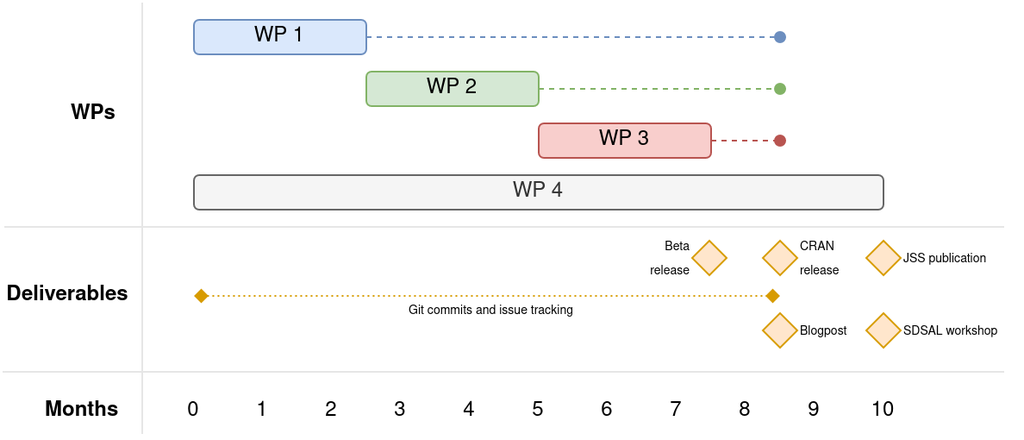

Project plan

## Start-up phase

The new version of `sfnetworks` builds upon the existing version, using the same collaboration platform, license, etc. First steps in the development of the new version have already been taken and some of the code is available on GitHub already. Therefore, the project does not require a start-up phase, and code writing can start right away.

## Technical delivery

The main deliverable of the project is the release of version 1.0 of the `sfnetworks` package. First, a beta-version will be released on the GitHub repository of `sfnetworks`. This is planned after completion of the first three WPs, in **June 2027**. The release will be accompanied by corresponding documentation, a changelog outlining how the new version is different from the previous, and an announcement to the user community with a request to test the new code. Once mature, the new version will be submitted to CRAN. This is planned for **July 2027**.

## Other aspects

Besides the technical delivery, the project aims to disseminate the work to a wide audience and stimulate community engagement. This is achieved through the following deliverables:

1. A blogpost on the r-spatial blog presenting the new CRAN release: **July 2027**
2. An academic article published in the Journal of Statistical Software: **September 2027**
3. A cross-language session on geospatial network analysis at the Spatial Data Science Across Languages workshop: **September 2027**

If requested, we are happy to also post the blog on the R Consortium blog, and host an online webinar about the new release.

We will continue to use the current GitHub repository of `sfnetworks`: https://github.com/luukvdmeer/sfnetworks. Here, an active user community is already present. The repository contains an [issue tracker](https://github.com/luukvdmeer/sfnetworks/issues) for bug reports and feature requests, a [discussion forum](https://github.com/luukvdmeer/sfnetworks/discussions), a [code of conduct](https://github.com/luukvdmeer/sfnetworks/blob/main/CODE_OF_CONDUCT.md) and detailed [contributing guidelines](https://github.com/luukvdmeer/sfnetworks/blob/main/CONTRIBUTING.md). The license of the package will remain unchanged: Apache 2.0. Regarding social media, we will post updates about the development on the personal [Mastodon account](https://datasci.social/@lvdmeer) of Lucas van der Meer, who has developed a good network in the field of open-source geospatial network analysis.

## Budget & funding plan

Lucas van der Meer is currently employed as a research assistant with a 20 h/week contract at the University of Salzburg. He works in research projects that apply geospatial network analysis, but are not specifically focused on software development and maintenance. The idea of this proposal is to be able to increase his working hours by 20%, i.e. 4 h/week on average, that he can dedicate exclusively to the development of `sfnetworks`. Over the total project runtime of 10 months, this translates to a total of 160 hours. His hourly income at the university is 53,20 EUR, equivalent 62,50 USD, using the exchange rate on May 1st 2026 of 1 EUR = 1.1743 USD. This sums to a total funding amount of **10.000 USD**. The funding will be split equally across each WP, meaning that every WP will be allocated 2.500 USD. Hence, the cost breakdown is as follows:

- **WP 1:** 2.500 USD (40h)
- **WP 2:** 2.500 USD (40h)
- **WP 3:** 2.500 USD (40h)
- **WP 4:** 2.500 USD (40h)
- **SUM:** 10.000 USD (160h)

# Success

## Definition of done

The project is considered done when all five deliverables outlined in the project plan have been delivered. That is, release of a beta-version of `sfnetworks v1.0` on GitHub, release of a stable version of `sfnetworks v1.0` on CRAN, publication of a blogpost describing the CRAN release on r-spatial, publication of an academic article in the Journal of Statistical Software (or similar), and co-hosting of a special session on geospatial network analysis at the Spatial Data Science Across Languages workshop (or similar).

## Measuring success

Progress will be tracked on the GitHub repository of `sfnetworks`. We will continuously commit the work to Git and push it to the repository, using structured commit messages as described in the [contributing guidelines](https://luukvdmeer.github.io/sfnetworks/CONTRIBUTING.html#structured-commit-messages). For each individual task, we will open an issue in the issue tracker, and close it once completed. Through these issues, we can also seek support from the community. The beta-release and CRAN release will be marked with a [GitHub release tag](https://docs.github.com/en/repositories/releasing-projects-on-github/managing-releases-in-a-repository), just like all other previous releases of `sfnetworks`. Each release will come with a detailed changelog, describing the implemented changes. The blogpost and journal publication will be openly available to everyone, and shared on social media. The special session at the Spatial Data Science Across Languages workshop will be marketed through the Spatial Data Science Across Languages community. Afterwards, we will write a summary of the session, and share it on social media. The session may also lead to a journal publication, but this falls outside the scope of the project.

## References

Antonov, Michael, Gábor Csárdi, Szabolcs Horvát, Kirill Müller, Tamás Nepusz, Daniel Noom, Maëlle Salmon, Vincent Traag, Brooke Foucault Welles, and Fabio Zanini. 2023. “Igraph Enables Fast and Robust Network Analysis Across Programming Languages.” *arXiv Preprint arXiv:2311.10260*. https://doi.org/10.48550/arXiv.2311.10260.

Arkilanian, Alex. 2026. *Dci: Calculates the Dendritic Connectivity Index in River Networks*. https://github.com/aarkilanian/dci.

Bystřický, Pavel Karel, Tereza Rutová, Vojtěch Brož, Magdalena Gajdošová, Petr Jan Juračka, Denis Copilaş-Ciocianu, and Adam Petrusek. 2022. “Distribution Patterns at Different Spatial Scales Reveal Reproductive Isolation and Frequent Syntopy Among Divergent Lineages of an Amphipod Species Complex in Western Carpathian Streams.” *Limnology and Oceanography* 67 (12): 2796–2808. https://doi.org/10.1002/lno.12239.

Cidre González, Adrián, Egor Kotov, and Rafael H. M. Pereira. 2026. *Duckspatial: R Interface to ’DuckDB’ Database with Spatial Extension*. https://cidree.github.io/duckspatial/.

Duong, Tarn. 2025. “Using Iterated Local Alignment to Aggregate Trajectory Data into a Traffic Flow Map.” *Journal of Location Based Services* 0 (0): 1–25. https://doi.org/10.1080/17489725.2025.2586277.

Evans, Jeffrey S. 2026. *GeNetIt: R Package for Spatial Graph-Theoretic Gravity Modelling*. https://github.com/jeffreyevans/GeNetIt.

Forgaci, Claudiu, and Francesco Nattino. 2025. *Rcrisp: Automate the Delineation of Urban River Spaces*. https://cityriverspaces.github.io/rcrisp/.

Harrisson, Katherine A., Luciano B. Beheregaray, Christopher M. Bice, Emily J. Booth, Chris J. Brauer, Gavin L. Butler, David Dawson, et al. 2025. “Otolith and Genomic Data Reveal Temporal Insights into Stocking Across a Large River Basin in a Mobile, Long-Lived Australian Freshwater Fish Species.” *Molecular Ecology* 34 (7): e17714. https://doi.org/10.1111/mec.17714.

Häusler, Mara-Magdalena, and Astrid Zabel. 2024. “Sites Side by Side: Can an Agglomeration Bonus with an Adjacency Rule Connect Agri-Environmental Sites?” *Ecological Economics* 224: 108287. https://doi.org/10.1016/j.ecolecon.2024.108287.

Larmet, Vincent. 2022. *cppRouting: Algorithms for Routing and Solving the Traffic Assignment Problem*. https://github.com/vlarmet/cppRouting.

Li, Xue, Kishan Prudhvi Guddanti, Samrat Acharya, Patrick Royer, Xiaoyuan Fan, and Marcelo Elizondo. 2023. “Smart Data Mapping for Connecting Power System Model and Geospatial Data.” In *2023 IEEE PES Innovative Smart Grid Technologies Latin America (ISGT-LA)*, 45–49. https://doi.org/10.1109/ISGT-LA56058.2023.10328353.

Mahajan, Sachit. 2024. “greenR: An Open-Source Framework for Quantifying Urban Greenness.” *Ecological Indicators* 163: 112108. https://doi.org/10.1016/j.ecolind.2024.112108.

Molné, Francesc, Giulia F. A. Donati, Janine Bolliger, Manuel Fischer, Max Maurer, and Peter M. Bach. 2023. “Supporting the Planning of Urban Blue-Green Infrastructure for Biodiversity: A Multi-Scale Prioritisation Framework.” *Journal of Environmental Management* 342: 118069. https://doi.org/10.1016/j.jenvman.2023.118069.

Nagkoulis, Nikolaos, Christos Adam, Ioannis Mamoutos, Stelios Katsanevakis, and Antonios D. Mazaris. 2025. “An Ecological Connectivity Dataset for Black Sea Obtained from Sea Currents.” *Data in Brief* 58: 111268. https://doi.org/10.1016/j.dib.2024.111268.

Padgham, Mark. 2019. “Dodgr: An r Package for Network Flow Aggregation.” *Transport Findings*. https://doi.org/10.32866/6945.

Panzeri, Simone, Aldo Clemente, Eleonora Arnone, Jorge Mateu, and Laura M. Sangalli. 2025. “Spatio-Temporal Intensity Estimation for Inhomogeneous Poisson Point Processes on Linear Networks: A Roughness Penalty Method.” *Spatial Statistics* 69: 100912. https://doi.org/10.1016/j.spasta.2025.100912.

Pebesma, Edzer. 2018. “Simple Features for R: Standardized Support for Spatial Vector Data.” *The R Journal* 10 (1): 439–46. https://doi.org/10.32614/RJ-2018-009.

Pedersen, Thomas Lin. 2025. *Tidygraph: A Tidy API for Graph Manipulation*. https://tidygraph.data-imaginist.com.

Priß, Deborah, John Wainwright, Dan Lawrence, Laura Turnbull, Christina Prell, Christodoulos Karittevlis, and Andreas A. Ioannides. 2025. “Filling the Gaps - Computational Approaches to Incomplete Archaeological Networks.” *Journal of Archaeological Method and Theory* 32 (1): 19. https://doi.org/10.1007/s10816-024-09688-z.

Rodriguez Rellan, C., S. Cassen, A. F. Carvalho, M. Murillo Barroso, and R. Fábregas Valcarce. 2023. “DESENREDANDO EL CAOS. UN ANÁLISIS DE LA CIRCULACIÓN DE LOS ADORNOS DE PIEDRA VERDE DURANTE LA PREHISTORIA RECIENTE DE LA PENÍNSULA IBÉRICA a TRAVÉS DE LA INVESTIGACIÓN DE REDES.” *Cuadernos De Prehistoria Y Arqueología De La Universidad De Granada* 33: 33–70. https://doi.org/10.30827/cpag.v33i0.28274.

Roussel, Jean-Romain, Jean-François Bourdon, Ilythia D. Morley, Nicholas C. Coops, and Alexis Achim. 2023. “Vectorial and Topologically Valid Segmentation of Forestry Road Networks from ALS Data.” *International Journal of Applied Earth Observation and Geoinformation* 118: 103267. https://doi.org/10.1016/j.jag.2023.103267.

Simoncic, V., M. Pozzar, C. Enaux, S. Deguen, and W. Kihal-Talantikite. 2022. “Optimization and Process Design Tools for Estimation of Weekly Exposure to Air Pollution Integrating Travel Patterns During Pregnancy.” *Open Journal of Statistics* 12: 408–32. https://doi.org/10.4236/ojs.2022.123026.

Tennekes, Martijn, and Andrea Gilardi. 2026. *Tmap.networks: Extension to ’Tmap’ for Creating Network Visualizations*. https://github.com/r-tmap/tmap.networks.

Thiede, Renate N., Inger N. Fabris-Rotelli, Pravesh Debba, and Christopher W. Cleghorn. 2023. “A Markov Chain Model for Geographical Accessibility.” *Spatial Statistics* 55: 100748. https://doi.org/10.1016/j.spasta.2023.100748.

Thorson, James T., Sean C. Anderson, Pamela Goddard, and Christopher N. Rooper. 2025. “tinyVAST: R Package with an Expressive Interface to Specify Lagged and Simultaneous Effects in Multivariate Spatio-Temporal Models.” *Global Ecology and Biogeography* 34 (4): e70035. https://doi.org/10.1111/geb.70035.

Tsyplenkov, Anatoly. 2025. *Centerline: Extract Centerline from Closed Polygons*. https://centerline.anatolii.nz.

Valls, F., and Á. Clua. 2023. “Modeling Barcelona Sidewalks: A High Resolution Urban Scale Assessment of the Geometric Attributes of the Walkable Network.” *PLoS ONE* 18: e0284630. https://doi.org/10.1371/journal.pone.0284630.

van der Meer, Lucas, Lorena Abad, Andrea Gilardi, and Robin Lovelace. 2024. *Sfnetworks: Tidy Geospatial Networks*. https://luukvdmeer.github.io/sfnetworks/.

van der Meer, Lucas, Christian Werner, and Martin Loidl. 2024. “Assessment of Bicycle Accessibility to Mobility Hubs Under Different Criteria for Cycling Network Quality.” *AGILE: GIScience Series* 5: 48. https://doi.org/10.5194/agile-giss-5-48-2024.

Yan, Yanyun, Wanggi Jaung, Daniel R. Richards, and L. Roman Carrasco. 2022. “Where Did the Ecosystem Services Value Go? Adaptive Supply, Demand and Valuation of New Urban Green Spaces.” *Resources, Conservation and Recycling* 187: 106616. https://doi.org/10.1016/j.resconrec.2022.106616.